# Assignment 3

Exploratory Data Analysis and Data Restructuring

Mubarak Mojoyinola, Geraldo Padilla

03-15-2022

# First part: exploratory analysis using gss_cat

**Research Questions**

1. How is age related to the amount of television a person reports watching?

1.1 Does there appear to be patterns in the missing data from the variable `tvhours` by different income and age levels?

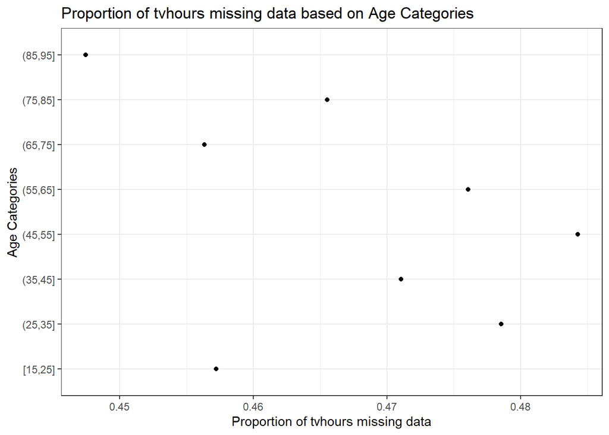

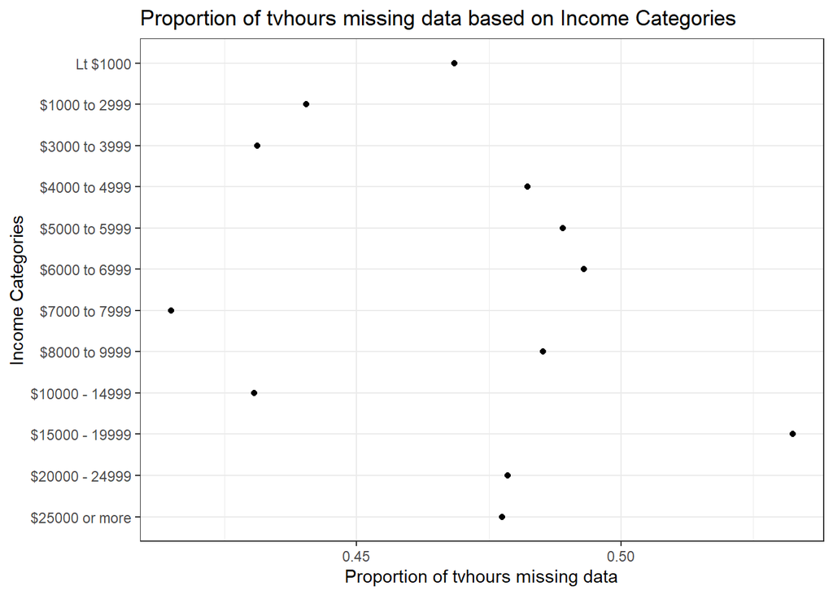

Based on age and income, it seems that there is no relationship between these variables and the amount of missing data in `tvhours`. We decided to use the proportion of missing data in relation to the number of responses within each category instead of the raw amount of missing data in order to adjust for the size of each category.

1.2 Does age appear to be related to the amount of time a person spends watching television?

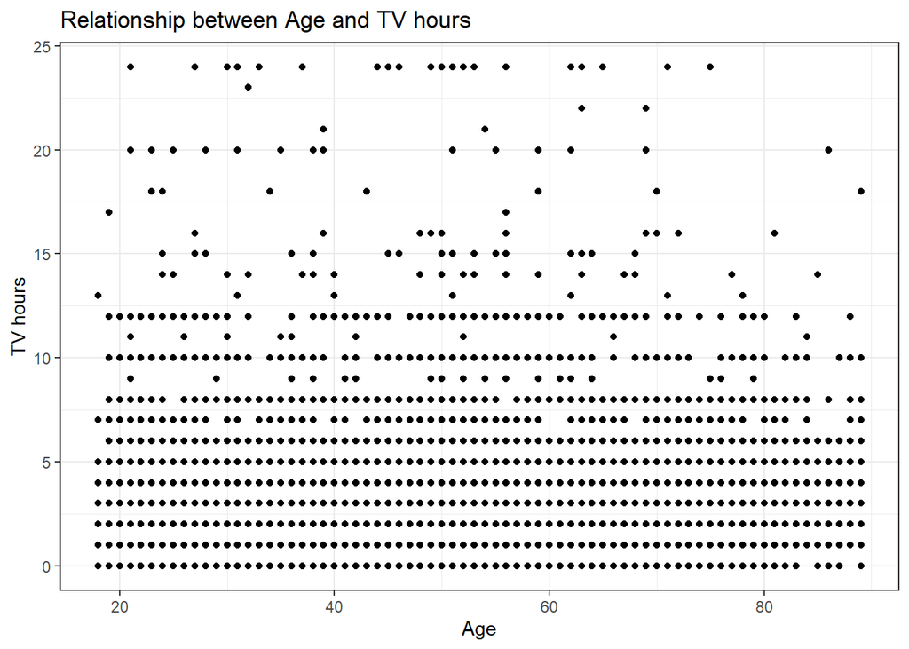

Based on the scatter plot, we can see that there is no apparent relationship between the amount of hours a person spends watching television and age.

# Second part

1. Read in the “ECLS_6250.csv” data file from the course website.

1.2 Using the head() function, print the first few rows of the data and using the dim() function, print out the dimensions of the data

```
## # A tibble: 6 x 22
##   CHILDID  S1_ID S2_ID S3_ID S4_ID S5_ID S6_ID S7_ID KURBAN_R GENDER  RACE
##   <chr>    <chr> <chr> <chr> <chr> <chr> <chr> <chr>    <dbl>  <dbl> <dbl>
## 1 0001001C 0001  0001  <NA>  0002  <NA>  <NA>  <NA>         1      2     1
## 2 0001002C 0001  0001  <NA>  6005  6005  A053  C001         1      2     1
## 3 0001003C 0001  0001  <NA>  9997  9997  <NA>  <NA>         1      2     1
## 4 0001004C 0001  0001  <NA>  6009  6009  <NA>  <NA>         1      1     1
## 5 0001005C 0001  0001  <NA>  0003  7197  <NA>  <NA>         1      2     1
## 6 0001006C 0001  0001  <NA>  6026  6026  <NA>  <NA>         1      1     1
## # ... with 11 more variables: C1R4MSCL <dbl>, C2R4MSCL <dbl>, C3R4MSCL <dbl>,
## #   C4R4MSCL <dbl>, C5R4MSCL <dbl>, C6R4MSCL <dbl>, C7R4MSCL <dbl>,
## #   W1SESL <dbl>, W3SESL <dbl>, W5SESL <dbl>, S2PUBLIC <dbl>
## [1] 21409    22
```

2. Verify that the data that are indeed missing are read in as missing values. Use the “ECLS_6250.pdf” codebook (found on the course website) to confirm values of missing data for each variable, these are listed for each variable directly in the codebook.

Missing data check

[output not shown]

The missing data is correctly included in the data set.

2.1 Compute the mean of the following two variables: “C4R4MSCL” and “W3SESL”.

```
## # A tibble: 1 x 2
##   mean_C4R4MSCL mean_W3SESL
##           <dbl>       <dbl>
## 1          61.1    -0.00397
```

3. Using the tidyr package, convert this data into an extra long format where the variables CHILDID, KURBAN_R, GENDER, and RACE are the id variables. The other data attributes would all represent data values to be restructured.

Using the head() function, print the first few rows of the data and using the dim() function, print out the dimensions of the data. Note, you should have 6 columns when you are done with this step.

```r
head(d1_long)
dim(d1_long)
```

```
## # A tibble: 6 x 6
##   CHILDID  KURBAN_R GENDER RACE  id_variable value
##   <chr>    <chr>    <chr>  <chr> <chr>       <chr>
## 1 0001001C 1        2      1     S1_ID       0001
## 2 0001001C 1        2      1     S2_ID       0001
## 3 0001001C 1        2      1     S3_ID       <NA>
## 4 0001001C 1        2      1     S4_ID       0002
## 5 0001001C 1        2      1     S5_ID       <NA>
## 6 0001001C 1        2      1     S6_ID       <NA>
## [1] 385362      6
```

4. Using the restructured data from #3 above, create three new variables that represent the type of variable (S = School, C = Child, W = family), the wave number, and remaining information. The type of variable and the wave number are the first and second characters of the variable names that were restructured (i.e. stacked) in #3. Hint, using the separate() function would be useful for this step and exploring some random rows of the data may be helpful using head() or tail() or sample_n().

Using the head() function, print the first few rows of the data and using the dim() function, print out the dimensions of the data. Note, you should have 8 columns when you are done with this step.

```r
head(d1_long_b)
dim(d1_long_b)
```

```
## # A tibble: 6 x 8
##   CHILDID  KURBAN_R GENDER RACE  var_type wave  other_info value
##   <chr>    <chr>    <chr>  <chr> <chr>    <chr> <chr>      <chr>
## 1 0001001C 1        2      1     S        1     ID         0001
## 2 0001001C 1        2      1     S        2     ID         0001
## 3 0001001C 1        2      1     S        3     ID         <NA>
## 4 0001001C 1        2      1     S        4     ID         0002
## 5 0001001C 1        2      1     S        5     ID         <NA>
## 6 0001001C 1        2      1     S        6     ID         <NA>
## [1] 385362      8
```

5. Using the restructured data from #4, combine the variable type (i.e., the attribute that is either S, C, or W) and left-over names. This new variable should be similar to the original variable names from when reading in the data from #1, but should not include the wave information in it. Hint, the unite() function should be helpful for this step.

Using the head() function, print the first few rows of the data and using the dim() function, print out the dimensions of the data. Note, you should have 7 columns when you are done with this step.

```r
head(d1_long_c)
dim(d1_long_c)
```

```
## # A tibble: 6 x 7
##   CHILDID  KURBAN_R GENDER RACE  ID    wave  value
##   <chr>    <chr>    <chr>  <chr> <chr> <chr> <chr>
## 1 0001001C 1        2      1     S_ID  1     0001
## 2 0001001C 1        2      1     S_ID  2     0001
## 3 0001001C 1        2      1     S_ID  3     <NA>
## 4 0001001C 1        2      1     S_ID  4     0002
## 5 0001001C 1        2      1     S_ID  5     <NA>
## 6 0001001C 1        2      1     S_ID  6     <NA>
## [1] 385362      7
```

6. Finally, using the restructured data from #5, widen the data set to create a variable for each unique value from the newly created variable from #5.

Using the head() function, print the first few rows of the data and using the dim() function, print out the dimensions of the data. Note, you should have 9 columns and fewer rows than #5 when you are done with this step.

```r
head(d1_long_d)
dim(d1_long_d)
```

```
## # A tibble: 6 x 9
##   CHILDID  KURBAN_R GENDER RACE  wave  S_ID  C_R4MSCL W_SESL S_PUBLIC
##   <chr>    <chr>    <chr>  <chr> <chr> <chr> <chr>    <chr>  <chr>
## 1 0001001C 1        2      1     1     0001  39.54    1.76   <NA>
## 2 0001001C 1        2      1     2     0001  50.1     <NA>   1
## 3 0001001C 1        2      1     3     <NA>  <NA>     <NA>   <NA>
## 4 0001001C 1        2      1     4     0002  96.04    <NA>   <NA>
## 5 0001001C 1        2      1     5     <NA>  <NA>     <NA>   <NA>
## 6 0001001C 1        2      1     6     <NA>  <NA>     <NA>   <NA>
## [1] 149863      9
```

Using the head() function, print the first few rows of the merged data and using the dim() function, print out the dimensions of the merged data.

```r
head(d3)
dim(d3)
```

```
## # A tibble: 6 x 13
##   CHILDID  KURBAN_R GENDER RACE  wave  S_ID  C_R4MSCL W_SESL S_PUBLIC CREGION
##   <chr>       <dbl> <chr>  <chr> <chr> <chr> <chr>    <chr>  <chr>      <dbl>
## 1 0001001C        1 2      1     1     0001  39.54    1.76   <NA>           1
## 2 0001001C        1 2      1     2     0001  50.1     <NA>   1              1
## 3 0001001C        1 2      1     3     <NA>  <NA>     <NA>   <NA>          NA
## 4 0001001C        1 2      1     4     0002  96.04    <NA>   <NA>           1
## 5 0001001C        1 2      1     5     <NA>  <NA>     <NA>   <NA>          NA
## 6 0001001C        1 2      1     6     <NA>  <NA>     <NA>   <NA>          NA
## # ... with 3 more variables: CS_TYPE2 <dbl>, S2KENRLS <dbl>, S2KPUPRI <dbl>
## [1] 149863     13
```

8. This question has a number of steps which are highlighted below in more detail.

Identify the 25 schools at wave 1 that have the highest proportion of female students and create a new data file that has the school ID and proportion of female students in the school. Note: Use the codebook to identify which code represents males and females. It may also be helpful, although not necessary, to create a new variable for gender.

```
## # A tibble: 25 x 2
##    S_ID  prop_fem
##    <chr>    <dbl>
##  1 0021         1
##  2 0097         1
##  3 0802         1
##  4 0879         1
##  5 0961         1
##  6 0970         1
##  7 1079         1
##  8 1178         1
##  9 1200         1
## 10 1207         1
## # ... with 15 more rows
```

Perform a filtering join that returns only the rows from the child level data (i.e., the final data from #7) at wave 1 that belong to the 25 schools that had the highest proportion of females at wave 1 (from step one of this question).

Using the head() function, print the first few rows of the data and using the dim() function, print out the dimensions of the data.

```r
head(d5)
dim(d5)
```

```
## # A tibble: 6 x 14
##   CHILDID  KURBAN_R GENDER RACE  wave  S_ID  C_R4MSCL W_SESL S_PUBLIC CREGION
##   <chr>       <dbl> <chr>  <chr> <chr> <chr> <chr>    <chr>  <chr>      <dbl>
## 1 0021001C        3 2      1     1     0021  24.19    -0.84  <NA>           1
## 2 0021002C        3 2      1     1     0021  25.04    -0.59  <NA>           1
## 3 0086002C        2 2      5     1     0086  <NA>     2.01   <NA>           1
## 4 0086003C        2 2      5     1     0086  <NA>     0.18   <NA>           1
## 5 0086004C        2 2      1     1     0086  38.73    1.05   <NA>           1
## 6 0086005C        2 2      4     1     0086  42.08    0.34   <NA>           1
## # ... with 4 more variables: CS_TYPE2 <dbl>, S2KENRLS <dbl>, S2KPUPRI <dbl>,
## #   gender <dbl>
## [1] 255  14
```